# Estimation of theta and delta

Kazik

02.06.2021

# INTRODUCTION

This note describe the process of fitting a non-linear function to sparse data.

The fitted non-linear function is a utility function of a dictator in a dictator game with other-regarding preferences as implied by the literature on social distance discounting (e.g., Strombach, et al., 2014; Ma, Pei, & Jin, 2015).

In the dictator game, the first player (the dictator) determines how to split an endowment (such as a cash prize) between themselves and the second player (the recipient). The dictator’s action determines the endowment, which ranges from giving nothing to giving all the endowment. The recipient has no influence over the outcome of the game, which means the recipient plays a passive role. For more information on the dictator game see Leder & Schütz (2018).

There are three main challenges:

- Due to decision-theoretical foundation we are interested in estimating the utility function for each participant. Thus, we cannot aggregate data.
- Because we need to estimate utility function for each participant, the preceding research cannot inform this analysis (reported values were at aggregated level). Moreover, sampled populations are different, so it would lead to biased results.
- The data for each respondent are very sparse (only 5 points). Consequently, issues with optimization algorithms are expected.

**Problem Description**

Assume that Player 1’s utility function is given by the equation $U(\pi_1,\pi_2)=U(\pi_1)+\frac{\theta}{1+\delta*SD}*U(\pi_2)$, where:

- $\pi_1$ is a payoff received by Player 1 (i.e., dictator)
- $\pi_2$ is a payoff received by Player 2
- $SD$ stands for Social Distance
- $\delta$ and $\theta$ are parameters of hyperbolic function

Because, this functional form is a substantive assumption we do not consider any modifications to it.

Respondents were asked a series of five questions about their indifference points between $\pi_1$ and $\pi_2$ for social distances 1, 5, 20, 50, and 100. Consequently each indifference point point is such that $U(\pi_1)=\frac{\theta}{1+\delta*SD}*U(\pi_2)$ for fixed $\pi_2$.

Given that $\pi_1$, $\pi_2$, and $SD$ are known and that $U(x)=x$ (i.e., linear utility of money), the problem boils down to finding $f(\theta,\delta)=\frac{\theta}{1+\delta*SD}$.

Substantively, why do we need $\delta$ and $\theta$? We need these parameters to obtain utility functions for every respondent. Such individual utility functions may be are later used to predict or model behaviour of individuals.

# SET-UP

```r
#load packages
library(tidyverse)
library(readxl)
library(minpack.lm)
library(saemix)
library(ggExtra)
library(nls2)
library(gamlss)
library(conflicted)

#solve conflicts
conflict_prefer("select", "dplyr")
conflict_prefer("filter", "dplyr")

#set directories
dir_in  <- file.path(getwd(), "input")
dir_out <- file.path(getwd(), "output")

#set seed
set.seed(48236)
```

# Data preparation

First, load data set for analysis.

```r
#data in long format
data_long <- read.csv(file.path(dir_in, "data_set_utility_function_sdd.csv")) %>%
  select(-X)
#data in wide format
data_wide <- pivot_wider(data_long,
                         id_cols = id,
                         names_from = sd,
                         values_from = ip)

head(data_long)
```

```
##   id  sd   ip
## 1  1   1 87.5
## 2  1   5 87.5
## 3  1  20 52.5
## 4  1  50 12.5
## 5  1 100  7.5
## 6  2   1 87.5
```

```r
head(data_wide)
```

```
## # A tibble: 6 × 6
##      id   `1`   `5`  `20`  `50` `100`
##   <int> <dbl> <dbl> <dbl> <dbl> <dbl>
## 1     1  87.5  87.5  52.5  12.5   7.5
## 2     2  87.5  87.5   2.5   2.5  87.5
## 3     3  87.5  87.5   2.5   7.5   7.5
## 4     4  72.5  72.5  32.5  22.5 -17.5
## 5     5  67.5  67.5  22.5   2.5   2.5
## 6     6  87.5  62.5  37.5  22.5  22.5
```

The variable “id” denotes a unique participant. Each observation is characterized by the social distance “sd”, and the indifference point “ip”. For each participant, we have 5 observations (i.e., points in ${\rm I\!R_+ \times I\!R_+}$). However, in some cases due to missing “ip” values we have only 4 or 3 observations. Visually, we want to fit the hyperbolic function to data like this:

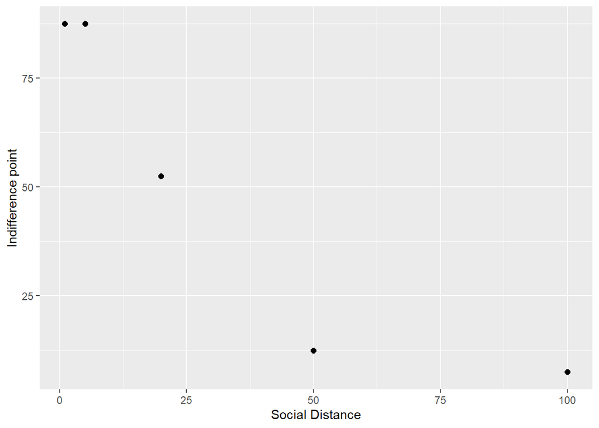

# Gauss-Newton algorithm

To run our algorithms we need some starting values. Let’s go with the simplest possibility, where starting values are a singular vector (i.e., $\theta$=1 and $\delta$=1).

```r
#Estimation of theta and delta by Gauss-Newton algorithm:

N=length(data_wide$id)
i=1

theta_gn <- c(0)
delta_gn <- c(0)

repeat{
  a <- filter(data_long, id==i)
  b <- try(nls(ip ~ (theta*75)/(1+delta*sd), data=a,
           start=c(theta=1, delta=1)))
  c=ifelse(isTRUE(class(b)=="try-error"), 1, 0)
  d <- summary(b)

  theta_gn[i]=ifelse(c==1, NA, d$coefficients[1,1])
  delta_gn[i]=ifelse(c==1, NA, d$coefficients[2,1])

i=i+1
if(i>N){
  break
}
}

est_gn <- data.frame(data_wide$id, theta_gn, delta_gn)
rm(N,i,a,b,c,d)

#Remarks:
#(1) Without "try()" the estimation using G-N algorithm
#    would stop after the first error.
```

The problem is that for 57 participants the values were not found. That is, for 13.44% of participants in the sample.

What is a source of this problem? The Gauss-Newton algorithm performs poorly when the residuals at the solution are large (i.e., when the model does not fit data well). Moreover, it may fail to find a solution if initial values are far from it (i.e., the convergence is not guaranteed if the starting point is not in the neighborhood of the minimum). Before we move to other algorithm we may try to find better starting values. As discussed in the appendix simple approaches failed (see Appendix B). Obviously, these attempts are nor sophisticated, but finding good starting values is a lot of work, so it may be worth to try other algorithm instead.

# Levenberg–Marquardt algorithm

```r
N=length(data_wide$id)
i=1

theta    <- c(0)
delta    <- c(0)
st.theta <- c(0)
st.delta <- c(0)
log_ll   <- c(0)
res      <- matrix(0, ncol = 5, nrow = N)

repeat{
  a <- filter(data_long, id==i)
  b <- nlsLM(ip ~ (theta*75)/(1+delta*sd), data=a,
      start=c(theta=1, delta=1),
      control=nls.lm.control(maxiter = 1024), lower=c(0,0), upper=c(5,5))
  c <- summary(b)
  theta[i]   =c$coefficients[1,1]
  delta[i]   =c$coefficients[2,1]
  st.theta[i]=c$coefficients[1,2]
  st.delta[i]=c$coefficients[2,2]
  log_ll[i]  =logLik(b)
  d <- residuals(b)
  res[i,1]=d[1]
  res[i,2]=d[2]
  res[i,3]=d[3]
  res[i,4]=d[4]
  res[i,5]=d[5]
i=i+1
if(i>N){
  break
  }
}

#Remarks:
#(1) Restrictions on parameters were added to avoid nonsensical values.
#(2) L-M algorithm managed to estimate parameters for all respondents,
#    so there was need to use "try()".
```

Before we move forward lets investigate if parameters’ values estimated by the L-M and G-N are the same (for those where G-N managed to estimate them).

```r
a <- theta_gn - sample$theta_nls
a <- a[!is.na(a)]

#used algorithms only approximate values, so small differences are expected.
b <- sum(a>-0.0001 & a<0.0001, na.rm = TRUE)
```

In 92.37% both algorithms provided almost identical values. Thus, the provided fairly similar estimates. Moreover, because the G-N was limited at 50 iterations and L-M at 1024 iterations, we can assume that obtained estimates are as accurate as possible (i.e., increasing the number of iterations would not change them significantly).

# Levenberg–Marquardt algorithm - problems

Upon a more detailed investigation we can spot that estimated parameters resulted, for some participants, in very peculiar functions. For example, we placed a constraint on $\delta$ and $\theta$ to avoid nonsensical fits like this one (it makes no sense form the substantive point of view, and it exists only because there are no observations for social distance $\in (20; 50)$):

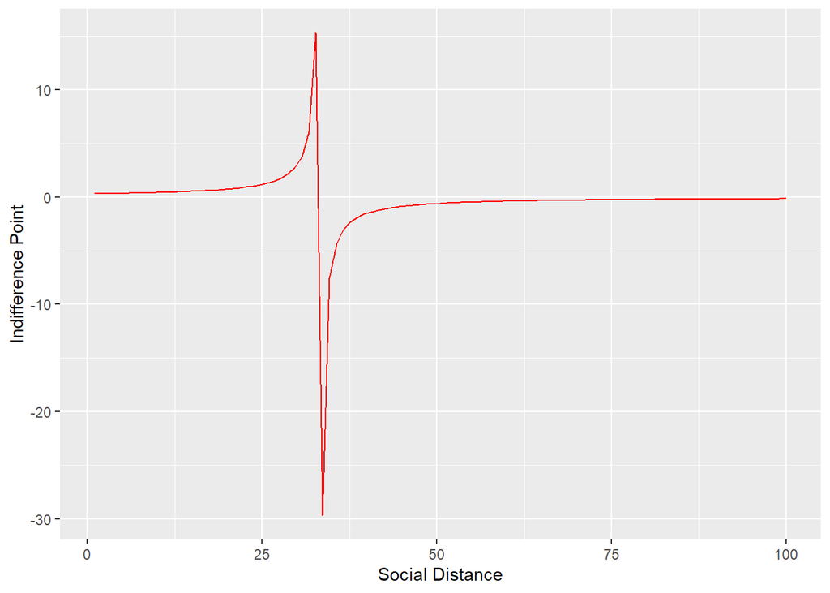

This is because we have a very limited information on each participant. It is not realistic to expect a good estimates for non-linear function with 2 parameters based on only 5 measurements. What can we do? A simple solution is to put some constrains on parameters (as already done in the code above), but it does not solve an underlying issue of small number of observations. One option is to use the SAEM algorithm.

# SAEM algorithm

The SAEM (Stochastic Approximation Expectation Maximisation) is a iterative and stochastic algorithm for calculating the maximum likelihood estimator in the general setting of incomplete data models. The underlying idea is to construct N Markov Chains (one for every participant) that converge to the conditional distributions, using at each step the complete data to calculate a new parameter vector (Comets, et al., 2017). In other words, (and slightly incorrectly) we can say that SAEM algorithm uses information on distribution to better estimate individual parameters.

Because SAEM algorithm does not work well with outliers we exclude them:

```r
i=1
j=0
th <-c(0)
repeat{
  th[i+j*4]=sample$theta_nls[i]
  th[i+1+j*4]=sample$theta_nls[i]
  th[i+2+j*4]=sample$theta_nls[i]
  th[i+3+j*4]=sample$theta_nls[i]
  th[i+4+j*4]=sample$theta_nls[i]
  i=i+1
  j=j+1
  if(i>N){
    break
  }
}

i=1
j=0
del <-c(0)
repeat{
  del[i+j*4]=sample$delta_nls[i]
  del[i+1+j*4]=sample$delta_nls[i]
  del[i+2+j*4]=sample$delta_nls[i]
  del[i+3+j*4]=sample$delta_nls[i]
  del[i+4+j*4]=sample$delta_nls[i]
  i=i+1
  j=j+1
  if(i>N){
    break
  }
}

data <- data.frame(data_long, th, del) %>%
  filter(th<3 & del<2 & !is.na(ip))

sample_long_cut <- data %>%
  select(id, sd, ip, th, del)
rm(data,th,del)

sample_cut <- sample %>%
  filter(theta_nls<3 & delta_nls<2)
```

Now we can move to parameter estimation:

```r
saemix.data <- saemixData(name.data       = sample_long_cut,
                          name.group      = "id",
                          name.predictors = "sd",
                          name.response   = "ip")

model1 <- function(psi,id,sd){
  theta <- psi[id,1]
  delta <- psi[id,2]
  sd <- sd[,1]
  hy_fun <- (theta*75)/(1+delta*sd)
  return(hy_fun)
}

saemix.model <- saemixModel(model = model1,
                            psi0  = matrix(c(1,1), ncol=2, dimnames =list(NULL, c("theta", "delta")))
)

saemix.options <- saemixControl(map=TRUE, fim=TRUE, ll.is=TRUE, displayProgress=FALSE, seed=632545, save = FALSE)

saemix.fit1    <- saemix(saemix.model, saemix.data, saemix.options)

psi <- psi(saemix.fit1)
sample_cut$theta_saemix <- psi$theta
sample_cut$delta_saemix <- psi$delta
```

# Comparison L-M and SAEM

Let’s compare values of parameters estimated by L-M and SAEM.

plot of values estimated by L-M

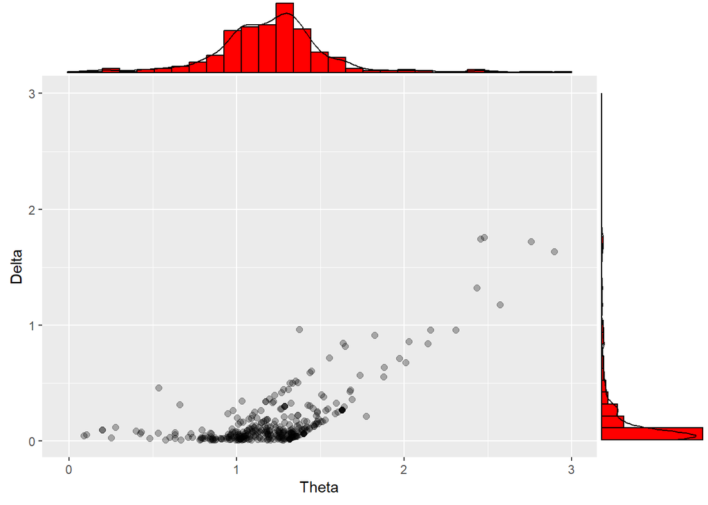

plot of values estimated by SAEM

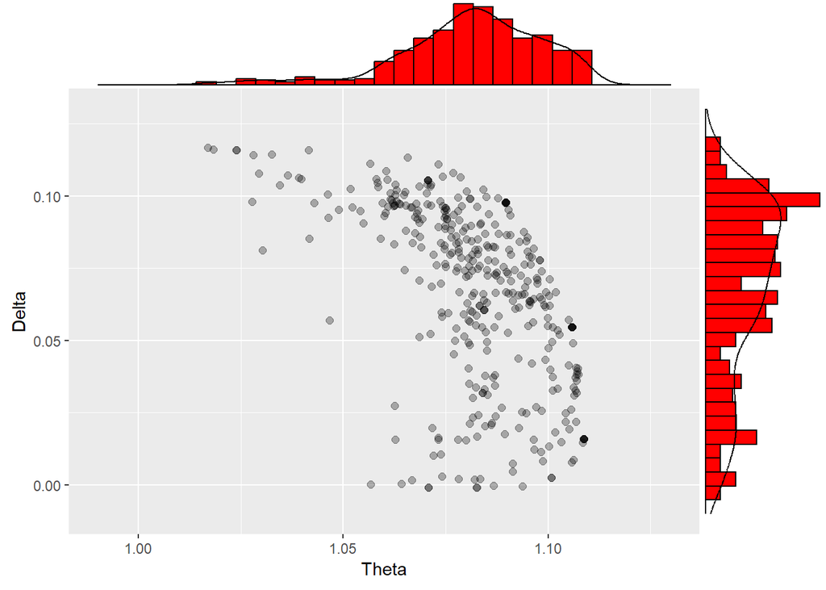

Plots put on each other:

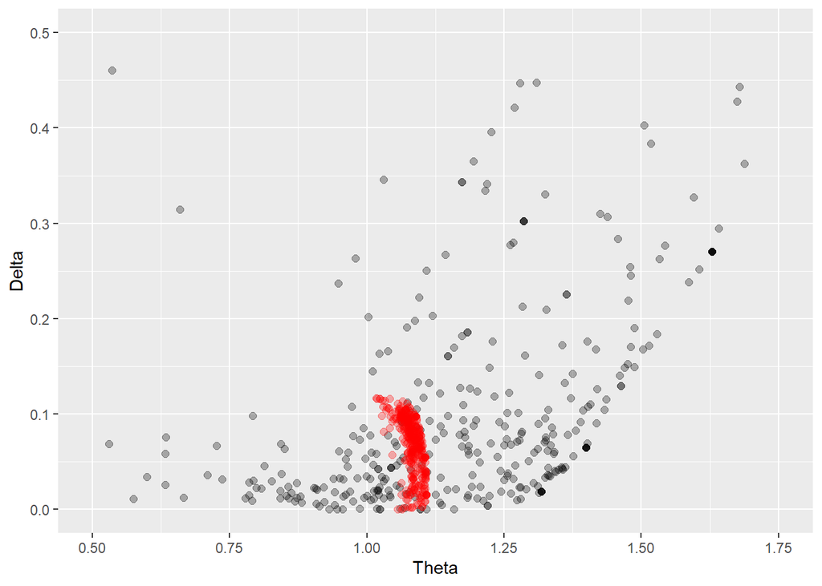

What about correlations (we compare them using sample without outliers so the number of observations is the same)?

Corr(theta_lm, theta_saem):

- pearson: 0.4559234
- spearman: 0.4795376
- kendall: 0.3634973

Corr(delta_lm, delta_saem):

- pearson: 0.5131267
- spearman: 0.8372368
- kendall: 0.7001316

Corr(theta_lm, delta_lm):

- pearson: 0.693847
- spearman: 0.5936733
- kendall: 0.4273376

Corr(theta_saem, delta_saem):

- pearson: -0.5315158
- spearman: -0.5825216
- kendall: -0.4276732

# Summary

To sum up, we obtained to two sets of estimates.

1. One using the Levenberg–Marquardt algorithm. The advantage of these results is that outliers are included.
2. Second using the SAEM algorithm. The advantage of these results is that they are less impacted by a single data point.

Given the advantages of respective sets of estimates it seems reasonable to use Levenberg–Marquardt algorithm’s results for the main analysis and SAEM algorithm’s for corroboration check.

# Appendix

## A: Remark on math behind Gauss-Newton and Levenberg–Marquardt algorithms

The problem we want to solve is: $minimize_x \ f(x)=\sum^m_{i=1}f_i(x)^2=F(x)^T F(x)$, where $F(x)=(f_1(x), f_2(x), ..., f_m(x))^T$

Note that:

- $\bigtriangledown f(x)=\bigtriangledown F(x) F(x)$
- $\bigtriangledown^2 f(x)=\bigtriangledown F(x) \bigtriangledown f(x)^T + \sum^m_{i=1}f_i(x) \bigtriangledown^2 f_i(x)$

Let $x_*$ be the solution, then $F(x_*)=0$.

Thus, it is reasonable to expect that $F(x) \approx 0$ for $x \approx x_*$.

It implies that: $\bigtriangledown^2 f_i(x) = \bigtriangledown F(x) \bigtriangledown F(x)^T + \sum^m_{i=1}f_i(x) \bigtriangledown^2 f_i(x) \approx \bigtriangledown F(x) \bigtriangledown F(x)^T$.

It means that the Hessian matrix can be found using only 1st derivatives (assuming that model fitts well to data). On this idea are based both the Gauss-Newton algorithm and the Levenberg–Marquardt algorithm.

To be more precise, the Gauss-Newton algorithm assumes that the term $\sum^m_{i=1}f_i(x) \bigtriangledown^2 f_i(x)$ is approximately 0. The Levenberg–Marquardt algorithm assumes that it is approximated by $\lambda I$, where $\lambda \geq 0$.

## B: Remark on starting points in G-N algorithm

We stated that some basic ideas for better estimation of starting points were tried. Here we describe them.

If the start values are not provided it does a cheap guess and assumes that all parameters are equal to 1.

We can linearize equation and use the OLS to find starting parameters.

$ip=\frac{\theta *75}{1+\delta *SD}$

$\frac{75}{ip}=\frac{1}{\theta}+\frac{\delta}{\theta}*SD$

```r
#select data for the first respondent
a <- filter(data_long, id==1)
#optymize using coeff from the linearized equation as a staring point
a$y <- 75/a$ip
a$x <- a$sd
b <- lm(y~x, a)
theta_start <- as.numeric(1/b$coefficients[1])
delta_start <- as.numeric(b$coefficients[2]*theta_start)


nls(ip ~ (theta*75)/(1+delta*sd), data=a, start = c(theta=theta_start, delta=delta_start))
```

```r
N=length(data_wide$id)
i=1

theta_gn2 <- c(0)
delta_gn2 <- c(0)
st1 <- expand.grid(theta = seq(-10, 100, len=30), delta = seq(-1, 20, len=30))

repeat{
  a <- filter(data_long, id==i)

  b <- try(nls2(ip ~ (theta*75)/(1+delta*sd), data=a, start = st1,
     algorithm = "random-search"))
  b2 <- ifelse(isTRUE(class(b)=="try-error"), 1, 0)
  theta_start <- ifelse(b2==1, 1, as.numeric(coef(b)[1]))
  delta_start <- ifelse(b2==1, 1, as.numeric(coef(b)[2]))

  c <- try(nls(ip ~ (theta*75)/(1+delta*sd), data=a,
           start=c(theta=theta_start, delta=delta_start)))
  d=ifelse(isTRUE(class(c)=="try-error"), 1, 0)
  e <- summary(c)

  theta_gn2[i]=ifelse(d==1, NA, e$coefficients[1,1])
  delta_gn2[i]=ifelse(d==1, NA, e$coefficients[2,1])

i=i+1
if(i>N){
  break
}
}

est_gn2 <- data.frame(data_wide$id, theta_gn2, delta_gn2)
rm(N,i,a,b,c,d)
```

Again, no significant improvement.

## C: Remark on assumptions made by the “saemix” package

The construction of SAEM and its implementation by the package saemix is rather complex, so explaining it here has no point (see Comets, et al., (2017) for details). However, one thing needs to be emphasized.

The statistical model for observation $y_{ij}$ is: $y_{ij}=f(\psi_i,x_{ij})+g(\psi_i,\sigma,x_{ij})$. Where, $f$ represents the structural model, describing the evolution of the process being modeled.

The package saemix assumes that the individual parameters $\psi_i$ can be modeled parametrically as a function of fixed effects $\mu$, individual random effects $\eta_i$, and subject-specific covariates $c_i$. It further assumes that $\eta_i$ follows some distribution. There are four available options determining the distribution of $\psi_i$. It can be normal, log-normal, or it can follow logit or probit transformation.

The assumption on the distribution of $\psi_i$ is important for accurate estimation. However, there exist other distributions that aforementioned ones.

```r
N=length(data_wide$id)

#we use the sample without the tail, because it is estimated by the saemix
fitDist(sample_cut$theta_nls, k=2)
fitDist(sample_cut$theta_nls, k=3.84)
 # "BCT", "Box-Cox t"
fitDist(sample_cut$theta_nls, k=log(N))
 # "NET", "Normal Exponential t"

fitDist(sample_cut$delta_nls, k=2)
 # it is the same for k=3.84 and k=log(N)
 # "PARETO2", "Pareto Type 2"
```

Thus, we see that neither $\theta$ nor $\delta$ is distributed as it can be assumed in saemix.

```r
#out of curiosity, what if we take the whole sample?

fitDist(sample$theta, k=2)
 # it is the same for k=3.84 and k=log(N)
 # "SHASH", "Sinh-Arcsinh"

fitDist(sample$delta, k=2)
fitDist(sample$delta, k=3.84)
fitDist(sample$delta, k=log(N))
 # for k=2 it is "ST1", "Skew t (Azzalini type 1)"
 # for k=3.84 and k=log(N) it is "PARETO2o", "Pareto Type 2"
```

# References

- Comets, E., Lavenu, A., & Lavielle, M. (2017). Parameter estimation in nonlinear mixed effect models using saemix, an R implementation of the SAEM algorithm. Journal of Statistical Software, 80, 1-41.
- Leder, J., & Schütz, A. (2018). Dictator game. Encyclopedia of personality and individual differences.
- Ma, Q., Pei, G., & Jin, J. (2015). What Makes You Generous? The Influence of Rural and Urban Rearing on Social Discounting in China. PLOS ONE, 10(7), e0133078. https://doi.org/10.1371/journal.pone.0133078
- Ruszczynski, A. (2011). Nonlinear optimization. Princeton university press.
- Strombach, T., Jin, J., Weber, B., Kenning, P., Shen, Q., Ma, Q., & Kalenscher, T. (2014). Charity begins at home: Cultural differences in social discounting and generosity. Journal of Behavioral Decision Making, 27(3), 235–245.